# Relations between Neural Reward Regions, ELS, and Social Support

## subgenual cingulate, vmPFC (Brodmann’s areas 25 and 11)

```r
require(ggplot2)
setwd("~/Documents/ELS/KIDMID/Analysis/ROI/52N_MSPSS.total")  #sgACC region from ant loss > gain cope 20, zstat 2
d = read.csv("anticipation_58subs_sgACC05-Sep-2014.csv") #contains ant PEs (1-4), ELS, MSPSS, age, and gender IVs
```

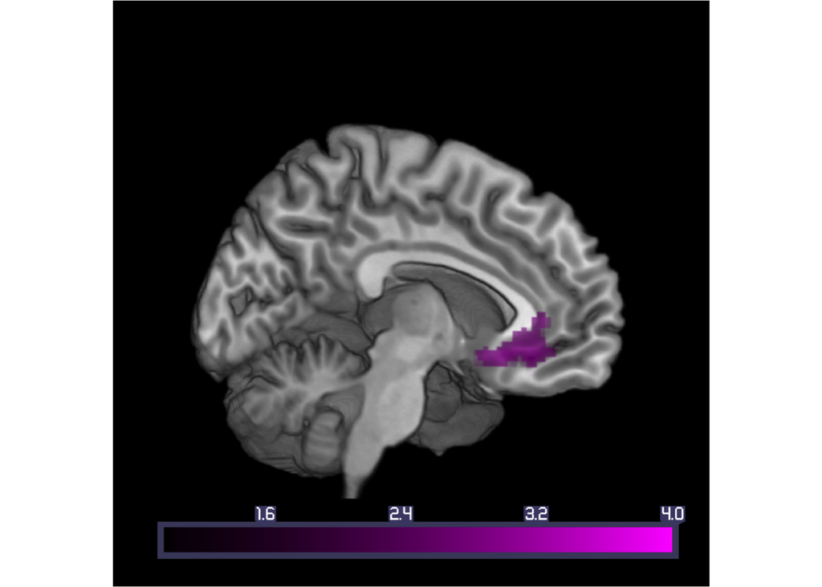

```r
library("png")
library("grid")
sgACC = readPNG("~/Documents/ELS/KIDMID/Analysis/ROI/52N_MSPSS.total/sgACC.png")
  grid.raster(sgACC)
```

```r
#<img src="~/Documents/ELS/KIDMID/Analysis/ROI/52N_MSPSS.total/sgACC.png" / >
#![sgACC]("~/Documents/ELS/KIDMID/Analysis/ROI/52N_MSPSS.total/sgACC.png")
```

The whole-brain MSPSS analyses excluded subject 17, which is an outlier for social support. Accordingly, I will exclude this participant when calculating the correlation coefficient and plotting the relation between social support and neural activation in sgACC for anticipation of loss > gain.

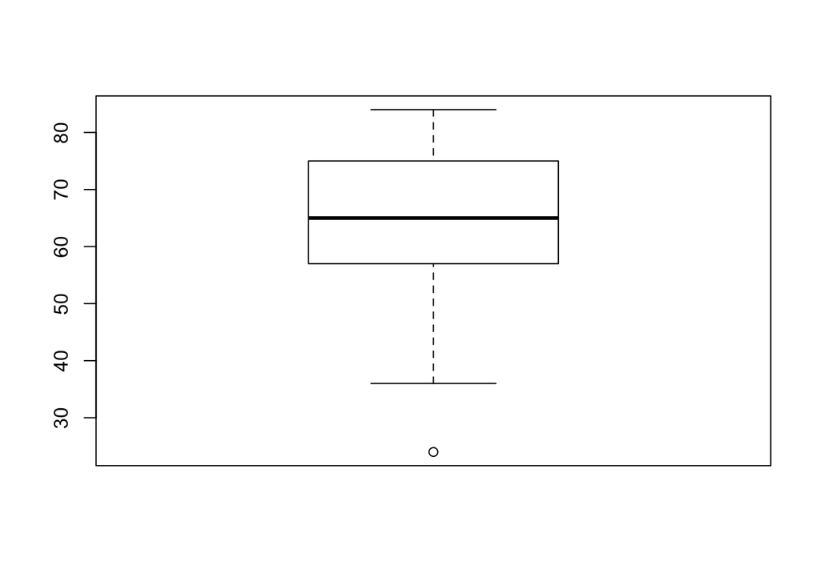

```r
#removing ss outlier
boxplot(d$ss.total) ## sub 17 is an outlier
```

Above shows a boxplot for the social support data - sub 17 is excluded (total social support score = 24) in below analyses.

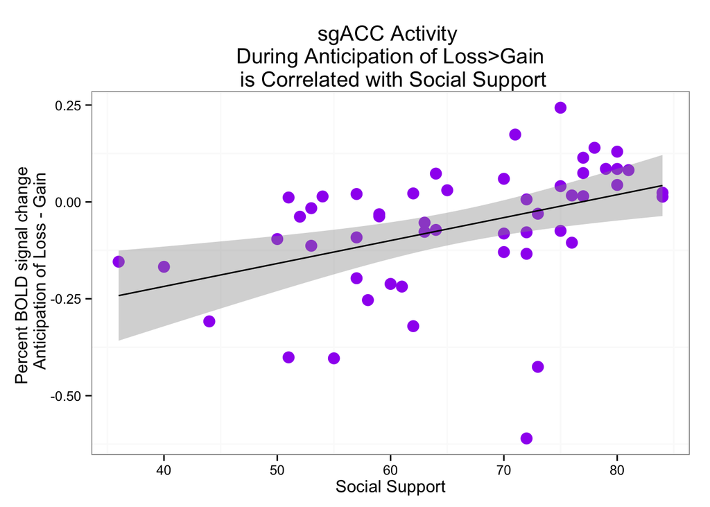

```r
d1 = d[-c(1,2,3,4,5,14),]
d1$lossvgain = d1$antloss - d1$antgain #contrast of ant loss > gain

ggplot(d1, aes(x=ss.total, y=lossvgain)) +
  geom_point(size=4, color="purple") +
  theme_bw() +
  theme(panel.grid.major = element_blank(), plot.title = element_text(size = 15, hjust=0.5)) +
  labs(x = "Social Support", y = "Percent BOLD signal change \n Anticipation of Loss - Gain") +
  ggtitle("sgACC Activity \n During Anticipation of Loss>Gain \n is Correlated with Social Support") +
  geom_smooth(method=lm, color="black")
```

```r
cor1 = cor.test(d1$lossvgain, d1$ss.total)
cor1
```

```
##
##  Pearson's product-moment correlation
##
## data:  d1$lossvgain and d1$ss.total
## t = 3.263, df = 50, p-value = 0.001989
## alternative hypothesis: true correlation is not equal to 0
## 95 percent confidence interval:
##  0.1650 0.6209
## sample estimates:
##   cor
## 0.419
```

```r
summary(lm(d1$lossvgain ~ d1$ss.total)) # r = .419, p = .002
```

```
##
## Call:
## lm(formula = d1$lossvgain ~ d1$ss.total)
##
## Residuals:
##     Min      1Q  Median      3Q     Max
## -0.5816 -0.0677  0.0282  0.1002  0.2540
##
## Coefficients:
##             Estimate Std. Error t value Pr(>|t|)
## (Intercept) -0.45486    0.12110   -3.76  0.00045 ***
## d1$ss.total  0.00592    0.00181    3.26  0.00199 **
## ---
## Signif. codes:  0 '***' 0.001 '**' 0.01 '*' 0.05 '.' 0.1 ' ' 1
##
## Residual standard error: 0.152 on 50 degrees of freedom
## Multiple R-squared:  0.176,  Adjusted R-squared:  0.159
## F-statistic: 10.6 on 1 and 50 DF,  p-value: 0.00199
```

```r
summary(lm(d1$lossvgain ~ d1$ss.total + d1$Age.at.scan)) # still holds controlling for age
```

```
##
## Call:
## lm(formula = d1$lossvgain ~ d1$ss.total + d1$Age.at.scan)
##
## Residuals:
##     Min      1Q  Median      3Q     Max
## -0.5817 -0.0682  0.0286  0.1008  0.2539
##
## Coefficients:
##                Estimate Std. Error t value Pr(>|t|)
## (Intercept)    -0.44424    0.27602   -1.61   0.1140
## d1$ss.total     0.00593    0.00184    3.22   0.0023 **
## d1$Age.at.scan -0.00096    0.02234   -0.04   0.9659
## ---
## Signif. codes:  0 '***' 0.001 '**' 0.01 '*' 0.05 '.' 0.1 ' ' 1
##
## Residual standard error: 0.153 on 49 degrees of freedom
## Multiple R-squared:  0.176,  Adjusted R-squared:  0.142
## F-statistic: 5.22 on 2 and 49 DF,  p-value: 0.00881
```

```r
summary(lm(d1$lossvgain ~ d1$ss.total + d1$Sex)) #still holds controlling for gender
```

```
##
## Call:
## lm(formula = d1$lossvgain ~ d1$ss.total + d1$Sex)
##
## Residuals:
##     Min      1Q  Median      3Q     Max
## -0.5570 -0.0599  0.0277  0.0937  0.2407
##
## Coefficients:
##             Estimate Std. Error t value Pr(>|t|)
## (Intercept) -0.42293    0.12653   -3.34   0.0016 **
## d1$ss.total  0.00567    0.00184    3.08   0.0033 **
## d1$SexM     -0.03870    0.04342   -0.89   0.3772
## ---
## Signif. codes:  0 '***' 0.001 '**' 0.01 '*' 0.05 '.' 0.1 ' ' 1
##
## Residual standard error: 0.152 on 49 degrees of freedom
## Multiple R-squared:  0.189,  Adjusted R-squared:  0.156
## F-statistic:  5.7 on 2 and 49 DF,  p-value: 0.00595
```

```r
summary(lm(d1$antloss ~ d1$ss.total)) # r = .26, p = .06
```

```
##
## Call:
## lm(formula = d1$antloss ~ d1$ss.total)
##
## Residuals:
##     Min      1Q  Median      3Q     Max
## -0.6899 -0.2206  0.0315  0.1793  0.6824
##
## Coefficients:
##             Estimate Std. Error t value Pr(>|t|)
## (Intercept) -0.72690    0.24824   -2.93   0.0051 **
## d1$ss.total  0.00716    0.00372    1.92   0.0599 .
## ---
## Signif. codes:  0 '***' 0.001 '**' 0.01 '*' 0.05 '.' 0.1 ' ' 1
##
## Residual standard error: 0.311 on 50 degrees of freedom
## Multiple R-squared:  0.069,  Adjusted R-squared:  0.0504
## F-statistic: 3.71 on 1 and 50 DF,  p-value: 0.0599
```

```r
summary(lm(d1$antgain ~ d1$ss.total)) # r = .05, p = .725
```

```
##
## Call:
## lm(formula = d1$antgain ~ d1$ss.total)
##
## Residuals:
##     Min      1Q  Median      3Q     Max
## -0.6937 -0.1520  0.0413  0.1845  0.7713
##
## Coefficients:
##             Estimate Std. Error t value Pr(>|t|)
## (Intercept) -0.27203    0.23385   -1.16     0.25
## d1$ss.total  0.00124    0.00350    0.35     0.73
##
## Residual standard error: 0.293 on 50 degrees of freedom
## Multiple R-squared:  0.00249,    Adjusted R-squared:  -0.0175
## F-statistic: 0.125 on 1 and 50 DF,  p-value: 0.725
```

**The correlation between activity in this region and social support seems to be strongest when considering the difference between anticipatory activity for gains v losses (r = .419, p = .002). When examining the relation between social support and anticipation of losses > baseline, the correlation is weaker (r = .26, p =.06), and it is non-existent for the anticipation of gains > baseline (r = .05, p = .73). This finding is a little puzzling in light of the below bar graph, which shows that the difference between anticipation of gains and losses is driven by the anticipation of gains.**

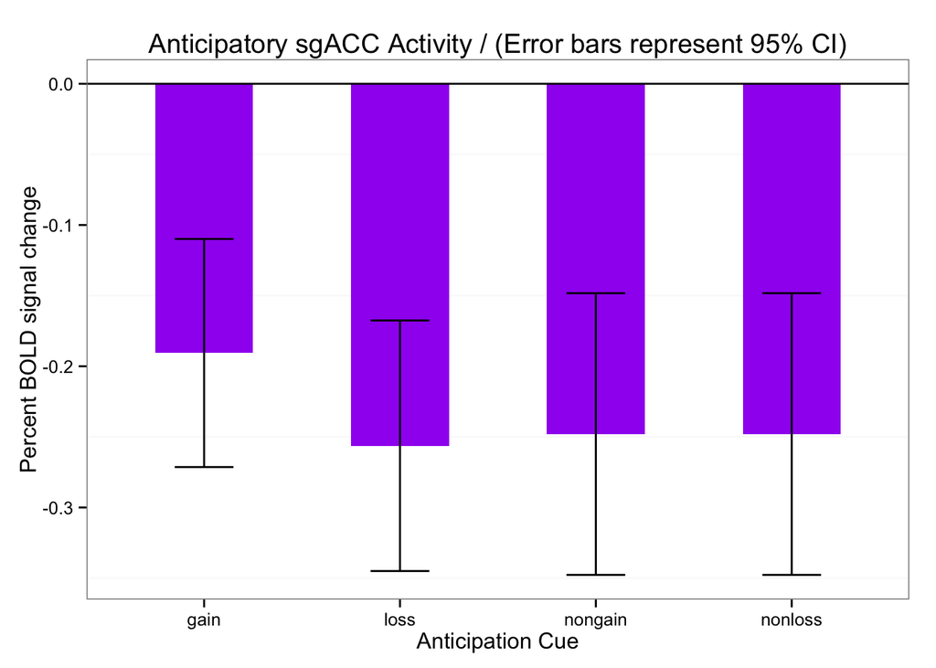

```r
#create dataframe to make bargraphs
anticipation = c(d1$antgain,d1$antloss,d1$antnongain,d1$antnongain)
condition = c(rep(x = "gain",times = 52), rep(x = "loss", times = 52), rep(x = "nongain", times = 52), rep(x = "nonloss", times = 52))
brainbar = data.frame(condition,anticipation)

sgACC.summary = data.frame(
  condition = levels(brainbar$condition),
  mean = tapply(brainbar$anticipation, brainbar$condition, mean),
  n = tapply(brainbar$anticipation, brainbar$condition, length),
  sd = tapply(brainbar$anticipation, brainbar$condition, sd)
  )

#calculate standard error of the mean
sgACC.summary$sem = sgACC.summary$sd/sqrt(sgACC.summary$n)

#calculate margin of error for CI
alpha = .05 #95% confidence interval
sgACC.summary$me = qt(1-alpha/2, df = sgACC.summary$n)*sgACC.summary$sem

#error bars represent 95% CI
#png('barplot.CI.vSTR.anticipation.png')
g1.CI = ggplot(sgACC.summary, aes(x = condition, y = mean)) +
  geom_bar(position = position_dodge(), stat="identity", fill="purple", width=.5) +
  geom_errorbar(aes(ymin=mean-me, ymax=mean+me), width=.3) +
  ggtitle("Anticipatory sgACC Activity / (Error bars represent 95% CI)") + # plot title
  geom_hline(yintercept=0, linetype = 1) +
  labs(x = "Anticipation Cue", y = "Percent BOLD signal change") +
  theme_bw() +
  #theme_classic()
  theme(panel.grid.major = element_blank()) # remove x and y major grid lines
print(g1.CI)
```

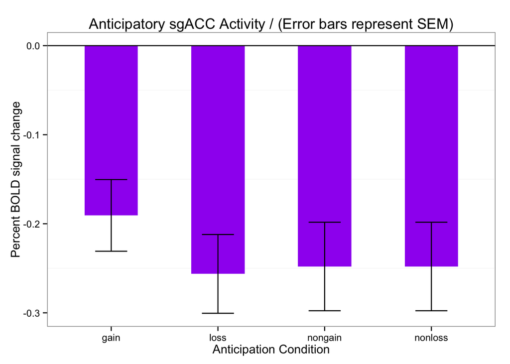

```r
#dev.off()

#error bars represent standard error of the mean
g1.SE = ggplot(sgACC.summary, aes(x = condition, y = mean)) +
  geom_bar(position = position_dodge(), stat="identity", fill="purple", width=.5) +
  geom_errorbar(aes(ymin=mean-sem, ymax=mean+sem), width=.3) +
  labs(x = "Anticipation Condition", y = "Percent BOLD signal change") +
  ggtitle("Anticipatory sgACC Activity / (Error bars represent SEM)") +
  geom_hline(yintercept=0, linetype = 1) +
  theme_bw() +
  theme(panel.grid.major = element_blank())
print(g1.SE)
```

```r
# boxplot(d1$antloss,d1$antgain)
# antgain.out = boxplot.stats(d1$antgain, do.out=TRUE)
# antgain.out$out  #sub 58, 65, 72

# d2 = d1[-c(40, 46, 51),]
# cor4 = cor.test(d2$lossvgain, d2$ss.total)
# cor4
# ggplot(d2, aes(x=ss.total, y=lossvgain)) +
#   geom_point(size=4, color="purple") +
#   theme_bw() +
#   theme(panel.grid.major = element_blank(), plot.title = element_text(size = 15, hjust=0.5)) +
#   labs(x = "Social Support", y = "Percent BOLD signal change \n Anticipation of Loss - Gain") +
#   ggtitle("sgACC Activity \n During Anticipation of Loss>Gain \n is Correlated with Social Support") +
#   geom_smooth(method=lm, color="black")
```

```r
r1 = t.test(d$antgain, d$antloss, paired=TRUE)
r1
```

```
##
##  Paired t-test
##
## data:  d$antgain and d$antloss
## t = 2.663, df = 57, p-value = 0.01005
## alternative hypothesis: true difference in means is not equal to 0
## 95 percent confidence interval:
##  0.01413 0.09981
## sample estimates:
## mean of the differences
##                 0.05697
```

```r
r2 = t.test(d$antloss, d$antnonloss, paired = TRUE)
r2
```

```
##
##  Paired t-test
##
## data:  d$antloss and d$antnonloss
## t = -0.4497, df = 57, p-value = 0.6546
## alternative hypothesis: true difference in means is not equal to 0
## 95 percent confidence interval:
##  -0.08185  0.05183
## sample estimates:
## mean of the differences
##                -0.01501
```

```r
r3 = t.test(d$antgain, d$antnongain, paired=TRUE)
r3
```

```
##
##  Paired t-test
##
## data:  d$antgain and d$antnongain
## t = 2.155, df = 57, p-value = 0.03539
## alternative hypothesis: true difference in means is not equal to 0
## 95 percent confidence interval:
##  0.004551 0.123978
## sample estimates:
## mean of the differences
##                 0.06426
```

```r
cor1 = cor.test(d$antloss,d$ss.total, na.action=na.omit)
cor2 = cor.test(d1$antloss,d1$ss.total)
d$lossvgain = d$antloss - d$antgain
```

```r
a = summary(lm(d1$lossvgain ~ d1$ss.total + d1$TotEventsExpUSE))
b = summary(lm(d1$lossvgain ~ d1$ss.total + d1$TotChildSubjRatUSE))
c = summary(lm(d1$lossvgain ~ d1$ss.total + d1$TotNumCategUSE))

#nothing sig for ant gain or ant loss
e = summary(lm(d1$antloss ~ d1$ss.total + d1$TotEventsExpUSE))
f = summary(lm(d1$antloss ~ d1$ss.total + d1$TotChildSubjRatUSE))
g = summary(lm(d1$antloss ~ d1$ss.total + d1$TotNumCategUSE))

h = summary(lm(d1$lossvgain ~ d1$ss.total * d1$TotEventsExpUSE))
i = summary(lm(d1$lossvgain ~ d1$ss.total * d1$TotChildSubjRatUSE))
j = summary(lm(d1$lossvgain ~ d1$ss.total * d1$TotNumCategUSE))

k = summary(lm(d$lossvgain ~ d$TotEventsExpUSE))
l = summary(lm(d$lossvgain ~ d$TotChildSubjRatUSE))
m = summary(lm(d$lossvgain ~ d$TotNumCategUSE))

n = summary(lm(d$antgain ~ d$TotEventsExpUSE))
o = summary(lm(d$antgain ~ d$TotChildSubjRatUSE))
p = summary(lm(d$antgain ~ d$TotNumCategUSE))

q = summary(lm(d$antgain ~ d$TotEventsExpUSE))
r = summary(lm(d$antgain ~ d$TotChildSubjRatUSE))
s = summary(lm(d$antgain ~ d$TotNumCategUSE))
```

**The relation with social support holds when controlling for age and gender.**

```r
summary(lm(d1$lossvgain ~ d1$ss.total + d1$Age.at.scan + d1$Sex))
```

```
##
## Call:
## lm(formula = d1$lossvgain ~ d1$ss.total + d1$Age.at.scan + d1$Sex)
##
## Residuals:
##     Min      1Q  Median      3Q     Max
## -0.5543 -0.0558  0.0268  0.0929  0.2402
##
## Coefficients:
##                Estimate Std. Error t value Pr(>|t|)
## (Intercept)    -0.48287    0.27970   -1.73   0.0907 .
## d1$ss.total     0.00560    0.00188    2.97   0.0046 **
## d1$Age.at.scan  0.00567    0.02353    0.24   0.8107
## d1$SexM        -0.04212    0.04609   -0.91   0.3654
## ---
## Signif. codes:  0 '***' 0.001 '**' 0.01 '*' 0.05 '.' 0.1 ' ' 1
##
## Residual standard error: 0.153 on 48 degrees of freedom
## Multiple R-squared:  0.19,   Adjusted R-squared:  0.139
## F-statistic: 3.75 on 3 and 48 DF,  p-value: 0.0169
```

```r
summary(lm(d1$lossvgain ~ d1$ss.fam + d1$Age.at.scan + d1$Sex))
```

```
##
## Call:
## lm(formula = d1$lossvgain ~ d1$ss.fam + d1$Age.at.scan + d1$Sex)
##
## Residuals:
##     Min      1Q  Median      3Q     Max
## -0.5319 -0.0491  0.0380  0.0789  0.2394
##
## Coefficients:
##                Estimate Std. Error t value Pr(>|t|)
## (Intercept)    -0.52644    0.29229   -1.80    0.078 .
## d1$ss.fam       0.01367    0.00513    2.67    0.010 *
## d1$Age.at.scan  0.01525    0.02359    0.65    0.521
## d1$SexM        -0.05756    0.04612   -1.25    0.218
## ---
## Signif. codes:  0 '***' 0.001 '**' 0.01 '*' 0.05 '.' 0.1 ' ' 1
##
## Residual standard error: 0.156 on 48 degrees of freedom
## Multiple R-squared:  0.164,  Adjusted R-squared:  0.112
## F-statistic: 3.14 on 3 and 48 DF,  p-value: 0.0336
```

```r
summary(lm(d1$lossvgain ~ d1$ss.fam * d1$Age.at.scan + d1$Sex))
```

```
##
## Call:
## lm(formula = d1$lossvgain ~ d1$ss.fam * d1$Age.at.scan + d1$Sex)
##
## Residuals:
##     Min      1Q  Median      3Q     Max
## -0.5349 -0.0583  0.0413  0.0864  0.1922
##
## Coefficients:
##                          Estimate Std. Error t value Pr(>|t|)
## (Intercept)               -3.5237     1.5627   -2.25    0.029 *
## d1$ss.fam                  0.1460     0.0680    2.15    0.037 *
## d1$Age.at.scan             0.2675     0.1313    2.04    0.047 *
## d1$SexM                   -0.0600     0.0449   -1.34    0.187
## d1$ss.fam:d1$Age.at.scan  -0.0111     0.0057   -1.95    0.057 .
## ---
## Signif. codes:  0 '***' 0.001 '**' 0.01 '*' 0.05 '.' 0.1 ' ' 1
##
## Residual standard error: 0.151 on 47 degrees of freedom
## Multiple R-squared:  0.227,  Adjusted R-squared:  0.161
## F-statistic: 3.45 on 4 and 47 DF,  p-value: 0.015
```

```r
summary(lm(d1$lossvgain ~ d1$ss.fri + d1$Age.at.scan + d1$Sex))
```

```
##
## Call:
## lm(formula = d1$lossvgain ~ d1$ss.fri + d1$Age.at.scan + d1$Sex)
##
## Residuals:
##     Min      1Q  Median      3Q     Max
## -0.5480 -0.0547  0.0201  0.0995  0.3001
##
## Coefficients:
##                 Estimate Std. Error t value Pr(>|t|)
## (Intercept)    -0.282665   0.272866   -1.04    0.305
## d1$ss.fri       0.011291   0.004347    2.60    0.012 *
## d1$Age.at.scan -0.000981   0.024653   -0.04    0.968
## d1$SexM        -0.050481   0.046609   -1.08    0.284
## ---
## Signif. codes:  0 '***' 0.001 '**' 0.01 '*' 0.05 '.' 0.1 ' ' 1
##
## Residual standard error: 0.156 on 48 degrees of freedom
## Multiple R-squared:  0.159,  Adjusted R-squared:  0.106
## F-statistic: 3.02 on 3 and 48 DF,  p-value: 0.0389
```

```r
summary(lm(d1$lossvgain ~ d1$ss.so + d1$Age.at.scan + d1$Sex))
```

```
##
## Call:
## lm(formula = d1$lossvgain ~ d1$ss.so + d1$Age.at.scan + d1$Sex)
##
## Residuals:
##     Min      1Q  Median      3Q     Max
## -0.5317 -0.0466  0.0395  0.0853  0.2471
##
## Coefficients:
##                Estimate Std. Error t value Pr(>|t|)
## (Intercept)    -0.41039    0.29524   -1.39    0.171
## d1$ss.so        0.00926    0.00491    1.89    0.065 .
## d1$Age.at.scan  0.01423    0.02442    0.58    0.563
## d1$SexM        -0.04702    0.04884   -0.96    0.340
## ---
## Signif. codes:  0 '***' 0.001 '**' 0.01 '*' 0.05 '.' 0.1 ' ' 1
##
## Residual standard error: 0.161 on 48 degrees of freedom
## Multiple R-squared:  0.107,  Adjusted R-squared:  0.0508
## F-statistic: 1.91 on 3 and 48 DF,  p-value: 0.141
```

**The following ROIs are defined by taking the conjunction (i.e., multiplying images with fslmaths) of the Harvard-Oxford Structural probabilistic atlas map with the functional activation from the main effect of the task (58 subjects). All striatal clusters (NAcc, putamen, and caudate) were created using the activation from cope 5: anticipation of gain > nongain. The insula was taken from cope 14: the outcome of loss > nonloss. The mPFC was taken from cope 13: outcome of gain > nongain.**

## bilateral NAcc

```r
require(ggplot2)
setwd("~/Documents/ELS/KIDMID/Analysis/ROI/58N_maineffect_HOatlas_union/")  #NAcc - conjuntion of H-O atlas left and right accumbens with cope5 (ant gain > nongain)
nacc = read.csv("ant+out_58subs_bilateralNAcc09-Sep-2014.csv") #contains ant PEs (1-4), ELS, MSPSS, age, and gender IVs
```

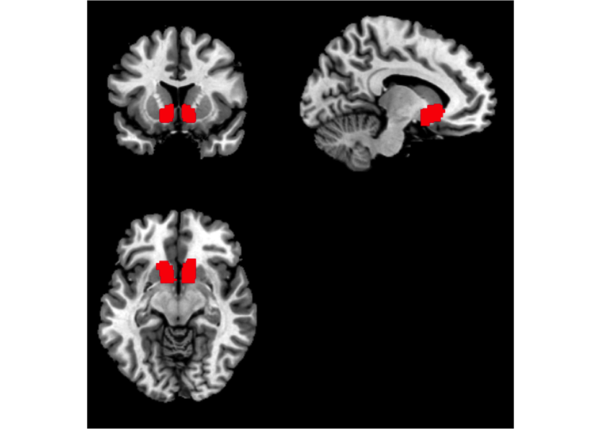

```r
library("png")
library("grid")
nacc.png = readPNG("~/Documents/ELS/KIDMID/Analysis/ROI/58N_maineffect_HOatlas_union/NAcc.png")
  grid.raster(nacc.png)
```

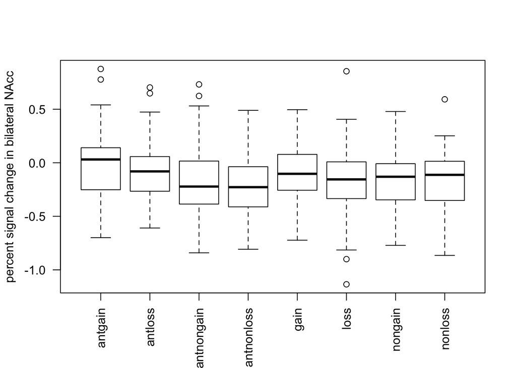

```r
boxplot(nacc$antgain, nacc$antloss, nacc$antnongain, nacc$antnonloss, nacc$gain, nacc$loss, nacc$nongain, nacc$nonloss, names = c("antgain","antloss","antnongain","antnonloss","gain","loss","nongain","nonloss"), ylab=("percent signal change in bilateral NAcc"), las =2)
```

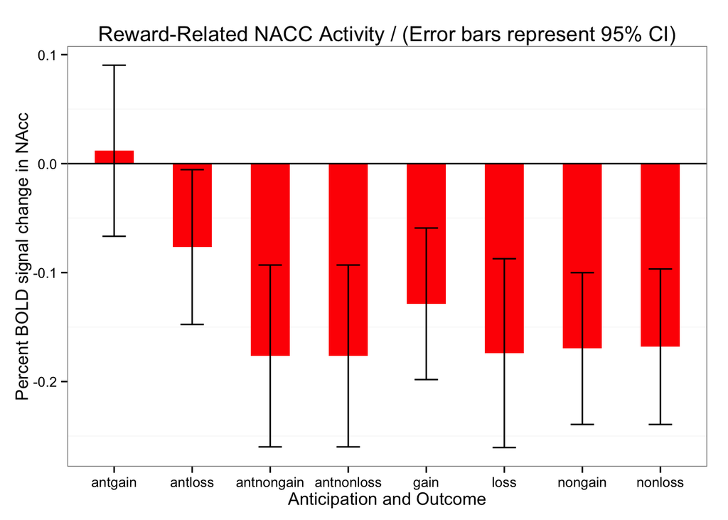

```r
#create dataframe to make bargraphs
nacc.pe = c(nacc$antgain,nacc$antloss,nacc$antnongain,nacc$antnongain,nacc$gain, nacc$loss, nacc$nongain, nacc$nonloss)
condition.2 = c(rep(x = "antgain", times = 58), rep(x = "antloss", times = 58), rep(x = "antnongain", times = 58), rep(x = "antnonloss", times = 58),rep(x = "gain", times = 58), rep(x = "loss", times = 58), rep(x = "nongain", times = 58), rep(x = "nonloss", times = 58))
naccbar = data.frame(condition.2,nacc.pe)

nacc.summary = data.frame(
  condition = levels(naccbar$condition.2),
  mean = tapply(naccbar$nacc.pe, naccbar$condition, mean),
  n = tapply(naccbar$nacc.pe, naccbar$condition, length),
  sd = tapply(naccbar$nacc.pe, naccbar$condition, sd)
  )
#calculate standard error of the mean
nacc.summary$sem = nacc.summary$sd/sqrt(nacc.summary$n)

#calculate margin of error for CI
alpha = .05 #95% confidence interval
nacc.summary$me = qt(1-alpha/2, df = nacc.summary$n)*nacc.summary$sem

#error bars represent 95% CI
#png('barplot.CI.vSTR.anticipation.png')
g2.CI = ggplot(nacc.summary, aes(x = condition, y = mean)) +
  geom_bar(position = position_dodge(), stat="identity", fill="red", width=.5) +
  geom_errorbar(aes(ymin=mean-me, ymax=mean+me), width=.3) +
  ggtitle("Reward-Related NACC Activity / (Error bars represent 95% CI)") + # plot title
  geom_hline(yintercept=0, linetype = 1) +
  labs(x = "Anticipation and Outcome", y = "Percent BOLD signal change in NAcc") +
  theme_bw() +
  #theme_classic()
  theme(panel.grid.major = element_blank()) # remove x and y major grid lines
print(g2.CI)
```

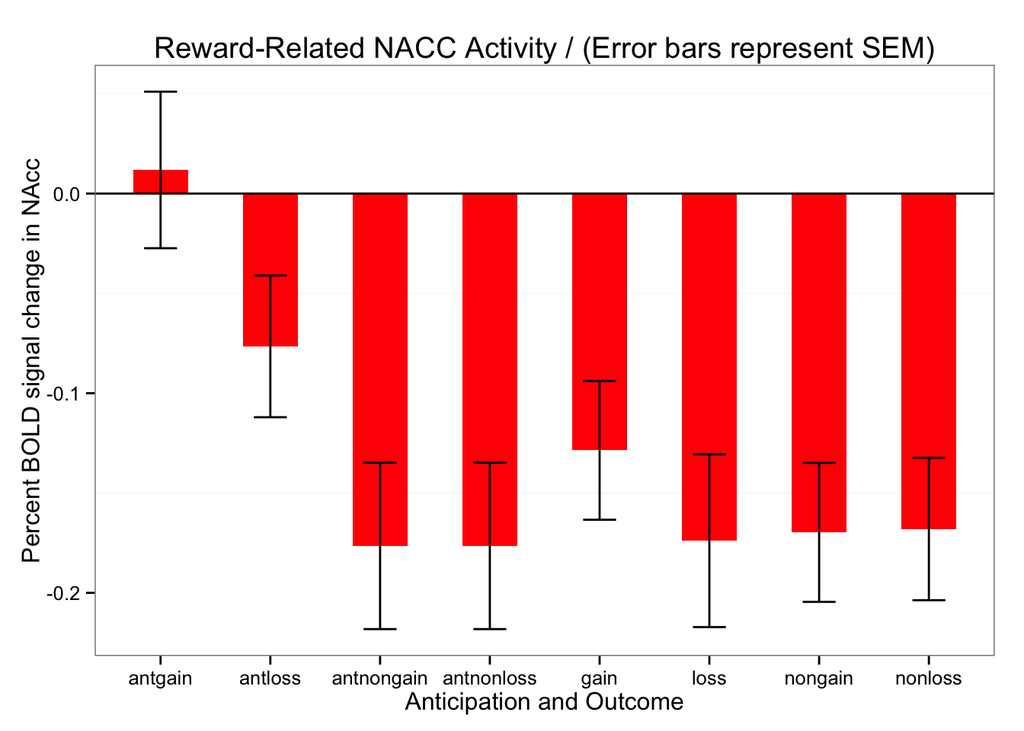

```r
#dev.off()

#error bars represent standard error of the mean
g2.SE = ggplot(nacc.summary, aes(x = condition, y = mean)) +
  geom_bar(position = position_dodge(), stat="identity", fill="red", width=.5) +
  geom_errorbar(aes(ymin=mean-sem, ymax=mean+sem), width=.3) +
  labs(x = "Anticipation and Outcome", y = "Percent BOLD signal change in NAcc") +
  ggtitle("Reward-Related NACC Activity / (Error bars represent SEM)") +
  geom_hline(yintercept=0, linetype = 1) +
  theme_bw() +
  theme(panel.grid.major = element_blank())
print(g2.SE)
```

**Anticipation**

```r
cor.test(nacc$antgain, nacc$TotEventsExpUSE) #ns
```

```
##
##  Pearson's product-moment correlation
##
## data:  nacc$antgain and nacc$TotEventsExpUSE
## t = 0.1432, df = 56, p-value = 0.8867
## alternative hypothesis: true correlation is not equal to 0
## 95 percent confidence interval:
##  -0.2404  0.2761
## sample estimates:
##     cor
## 0.01913
```

```r
cor.test(nacc$antgain, nacc$TotNumCategUSE) #ns
```

```
##
##  Pearson's product-moment correlation
##
## data:  nacc$antgain and nacc$TotNumCategUSE
## t = 0.13, df = 56, p-value = 0.8971
## alternative hypothesis: true correlation is not equal to 0
## 95 percent confidence interval:
##  -0.2420  0.2744
## sample estimates:
##     cor
## 0.01736
```

```r
cor.test(nacc$antgain, nacc$TotChildSubjRatUSE) #ns
```

```
##
##  Pearson's product-moment correlation
##
## data:  nacc$antgain and nacc$TotChildSubjRatUSE
## t = 0.4325, df = 56, p-value = 0.667
## alternative hypothesis: true correlation is not equal to 0
## 95 percent confidence interval:
##  -0.2036  0.3114
## sample estimates:
##    cor
## 0.0577
```

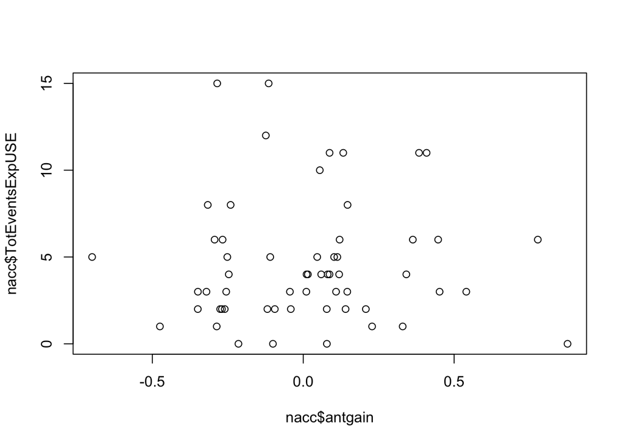

```r
plot(nacc$antgain, nacc$TotEventsExpUSE) # example plot, no relation
```

```r
cor.test(nacc$antloss, nacc$TotEventsExpUSE) #ns
```

```
##
##  Pearson's product-moment correlation
##
## data:  nacc$antloss and nacc$TotEventsExpUSE
## t = 0.1996, df = 56, p-value = 0.8425
## alternative hypothesis: true correlation is not equal to 0
## 95 percent confidence interval:
##  -0.2332  0.2830
## sample estimates:
##     cor
## 0.02667
```

```r
cor.test(nacc$antloss, nacc$TotNumCategUSE) #ns
```

```
##
##  Pearson's product-moment correlation
##
## data:  nacc$antloss and nacc$TotNumCategUSE
## t = 0.2245, df = 56, p-value = 0.8232
## alternative hypothesis: true correlation is not equal to 0
## 95 percent confidence interval:
##  -0.2301  0.2861
## sample estimates:
##     cor
## 0.02999
```

```r
cor.test(nacc$antloss, nacc$TotChildSubjRatUSE) #ns
```

```
##
##  Pearson's product-moment correlation
##
## data:  nacc$antloss and nacc$TotChildSubjRatUSE
## t = 0.5736, df = 56, p-value = 0.5686
## alternative hypothesis: true correlation is not equal to 0
## 95 percent confidence interval:
##  -0.1855  0.3282
## sample estimates:
##     cor
## 0.07642
```

```r
nacc$antgainvnongain = nacc$antgain - nacc$antnongain
nacc$antlossvnonloss = nacc$antloss - nacc$antnonloss

cor.test(nacc$antgainvnongain,nacc$TotEventsExpUSE) #ns
```

```
##
##  Pearson's product-moment correlation
##
## data:  nacc$antgainvnongain and nacc$TotEventsExpUSE
## t = -0.3624, df = 56, p-value = 0.7184
## alternative hypothesis: true correlation is not equal to 0
## 95 percent confidence interval:
##  -0.3029  0.2126
## sample estimates:
##      cor
## -0.04837
```

```r
cor.test(nacc$antgainvnongain, nacc$TotNumCategUSE) #ns
```

```
##
##  Pearson's product-moment correlation
##
## data:  nacc$antgainvnongain and nacc$TotNumCategUSE
## t = -0.1636, df = 56, p-value = 0.8706
## alternative hypothesis: true correlation is not equal to 0
## 95 percent confidence interval:
##  -0.2786  0.2378
## sample estimates:
##      cor
## -0.02186
```

```r
cor.test(nacc$antgainvnongain, nacc$TotChildSubjRatUSE) #ns
```

```
##
##  Pearson's product-moment correlation
##
## data:  nacc$antgainvnongain and nacc$TotChildSubjRatUSE
## t = 0.0307, df = 56, p-value = 0.9756
## alternative hypothesis: true correlation is not equal to 0
## 95 percent confidence interval:
##  -0.2545  0.2621
## sample estimates:
##      cor
## 0.004107
```

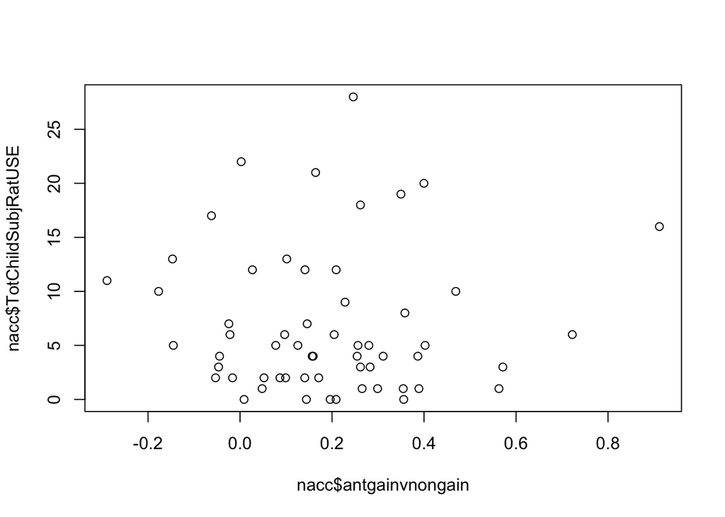

```r
plot(nacc$antgainvnongain,nacc$TotChildSubjRatUSE)
```

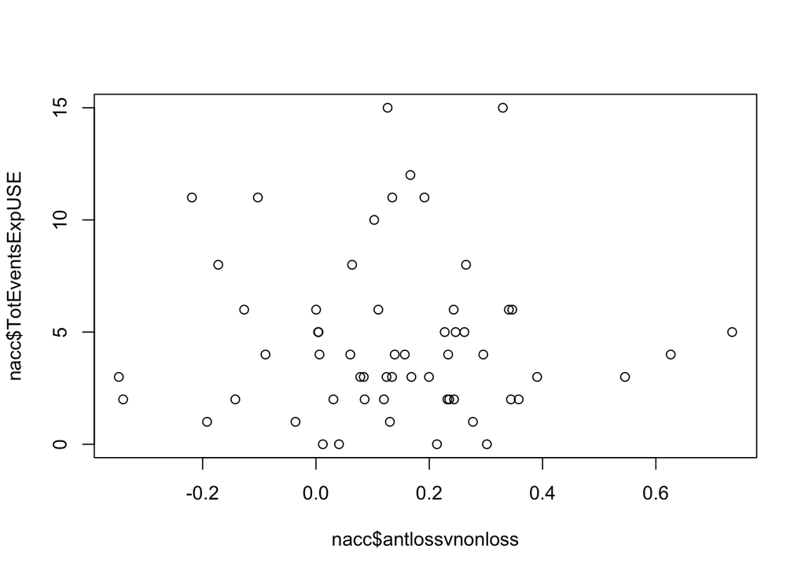

```r
#summary(lm(nacc$TotChildSubjRatUSE ~ nacc$antgainvnongain)) #same as above

plot(nacc$antlossvnonloss, nacc$TotEventsExpUSE)
```

```r
cor.test(nacc$antlossvnonloss,nacc$TotEventsExpUSE) #ns
```

```
##
##  Pearson's product-moment correlation
##
## data:  nacc$antlossvnonloss and nacc$TotEventsExpUSE
## t = -0.1214, df = 56, p-value = 0.9038
## alternative hypothesis: true correlation is not equal to 0
## 95 percent confidence interval:
##  -0.2734  0.2431
## sample estimates:
##      cor
## -0.01622
```

```r
cor.test(nacc$antlossvnonloss, nacc$TotNumCategUSE) #ns
```

```
##
##  Pearson's product-moment correlation
##
## data:  nacc$antlossvnonloss and nacc$TotNumCategUSE
## t = 0.0405, df = 56, p-value = 0.9678
## alternative hypothesis: true correlation is not equal to 0
## 95 percent confidence interval:
##  -0.2532  0.2633
## sample estimates:
##      cor
## 0.005413
```

```r
cor.test(nacc$antlossvnonloss, nacc$TotChildSubjRatUSE) #ns
```

```
##
##  Pearson's product-moment correlation
##
## data:  nacc$antlossvnonloss and nacc$TotChildSubjRatUSE
## t = 0.2746, df = 56, p-value = 0.7846
## alternative hypothesis: true correlation is not equal to 0
## 95 percent confidence interval:
##  -0.2237  0.2922
## sample estimates:
##     cor
## 0.03667
```

```r
summary(lm(nacc$antgainvnongain ~ nacc$TotChildSubjRatUSE * nacc$Age.at.scan)) #ns
```

```
##
## Call:
## lm(formula = nacc$antgainvnongain ~ nacc$TotChildSubjRatUSE *
##     nacc$Age.at.scan)
##
## Residuals:
##     Min      1Q  Median      3Q     Max
## -0.4924 -0.1241 -0.0046  0.1201  0.7200
##
## Coefficients:
##                                          Estimate Std. Error t value
## (Intercept)                               0.67483    0.53626    1.26
## nacc$TotChildSubjRatUSE                  -0.03033    0.05845   -0.52
## nacc$Age.at.scan                         -0.04177    0.04588   -0.91
## nacc$TotChildSubjRatUSE:nacc$Age.at.scan  0.00262    0.00506    0.52
##                                          Pr(>|t|)
## (Intercept)                                  0.21
## nacc$TotChildSubjRatUSE                      0.61
## nacc$Age.at.scan                             0.37
## nacc$TotChildSubjRatUSE:nacc$Age.at.scan     0.61
##
## Residual standard error: 0.221 on 54 degrees of freedom
## Multiple R-squared:  0.0161, Adjusted R-squared:  -0.0386
## F-statistic: 0.294 on 3 and 54 DF,  p-value: 0.829
```

```r
summary(lm(nacc$antgainvnongain ~ nacc$TotChildSubjRatUSE * nacc$Sex)) #ns
```

```
##
## Call:
## lm(formula = nacc$antgainvnongain ~ nacc$TotChildSubjRatUSE *
##     nacc$Sex)
##
## Residuals:
##     Min      1Q  Median      3Q     Max
## -0.4726 -0.1343 -0.0158  0.1116  0.6925
##
## Coefficients:
##                                   Estimate Std. Error t value Pr(>|t|)
## (Intercept)                       1.83e-01   5.31e-02    3.45   0.0011 **
## nacc$TotChildSubjRatUSE           1.23e-05   4.99e-03    0.00   0.9980
## nacc$SexM                         2.95e-03   9.35e-02    0.03   0.9750
## nacc$TotChildSubjRatUSE:nacc$SexM 2.04e-03   1.25e-02    0.16   0.8712
## ---
## Signif. codes:  0 '***' 0.001 '**' 0.01 '*' 0.05 '.' 0.1 ' ' 1
##
## Residual standard error: 0.222 on 54 degrees of freedom
## Multiple R-squared:  0.00151,    Adjusted R-squared:  -0.054
## F-statistic: 0.0272 on 3 and 54 DF,  p-value: 0.994
```

## There is no relation between early life stress and bilateral NAcc activation during the anticipation of gains or losses.

```r
summary(lm(nacc$antgainvnongain ~ nacc$ss.total, na.action = na.omit))
```

```
##
## Call:
## lm(formula = nacc$antgainvnongain ~ nacc$ss.total, na.action = na.omit)
##
## Residuals:
##     Min      1Q  Median      3Q     Max
## -0.4427 -0.1538 -0.0083  0.1190  0.7471
##
## Coefficients:
##               Estimate Std. Error t value Pr(>|t|)
## (Intercept)    0.29712    0.15182    1.96    0.056 .
## nacc$ss.total -0.00184    0.00229   -0.80    0.426
## ---
## Signif. codes:  0 '***' 0.001 '**' 0.01 '*' 0.05 '.' 0.1 ' ' 1
##
## Residual standard error: 0.214 on 51 degrees of freedom
##   (5 observations deleted due to missingness)
## Multiple R-squared:  0.0125, Adjusted R-squared:  -0.00688
## F-statistic: 0.645 on 1 and 51 DF,  p-value: 0.426
```

```r
summary(lm(nacc$antlossvnonloss ~ nacc$ss.total, na.action = na.omit)) # p = .04
```

```
##
## Call:
## lm(formula = nacc$antlossvnonloss ~ nacc$ss.total, na.action = na.omit)
##
## Residuals:
##     Min      1Q  Median      3Q     Max
## -0.4515 -0.1338  0.0242  0.1360  0.5593
##
## Coefficients:
##               Estimate Std. Error t value Pr(>|t|)
## (Intercept)   -0.15473    0.14531   -1.06    0.292
## nacc$ss.total  0.00458    0.00219    2.09    0.042 *
## ---
## Signif. codes:  0 '***' 0.001 '**' 0.01 '*' 0.05 '.' 0.1 ' ' 1
##
## Residual standard error: 0.205 on 51 degrees of freedom
##   (5 observations deleted due to missingness)
## Multiple R-squared:  0.0788, Adjusted R-squared:  0.0608
## F-statistic: 4.36 on 1 and 51 DF,  p-value: 0.0417
```

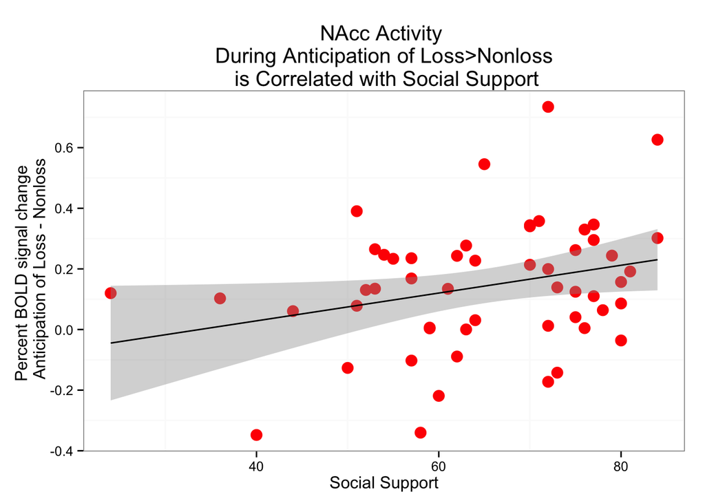

```r
ggplot(nacc, aes(x=ss.total, y=antlossvnonloss)) +
  geom_point(size=4, color="red") +
  theme_bw() +
  theme(panel.grid.major = element_blank(), plot.title = element_text(size = 15, hjust=0.5)) +
  labs(x = "Social Support", y = "Percent BOLD signal change \n Anticipation of Loss - Nonloss") +
  ggtitle("NAcc Activity \n During Anticipation of Loss>Nonloss \n is Correlated with Social Support") +
  geom_smooth(method=lm, color="black")
```

```r
summary(lm(nacc$antlossvnonloss ~ nacc$ss.total * nacc$TotEventsExpUSE, na.action = na.omit))
```

```
##
## Call:
## lm(formula = nacc$antlossvnonloss ~ nacc$ss.total * nacc$TotEventsExpUSE,
##     na.action = na.omit)
##
## Residuals:
##     Min      1Q  Median      3Q     Max
## -0.4637 -0.1301  0.0232  0.1253  0.5587
##
## Coefficients:
##                                     Estimate Std. Error t value Pr(>|t|)
## (Intercept)                        -0.050607   0.251959   -0.20     0.84
## nacc$ss.total                       0.003157   0.003707    0.85     0.40
## nacc$TotEventsExpUSE               -0.022801   0.045143   -0.51     0.62
## nacc$ss.total:nacc$TotEventsExpUSE  0.000315   0.000668    0.47     0.64
##
## Residual standard error: 0.208 on 49 degrees of freedom
##   (5 observations deleted due to missingness)
## Multiple R-squared:  0.0839, Adjusted R-squared:  0.0278
## F-statistic:  1.5 on 3 and 49 DF,  p-value: 0.227
```

```r
summary(lm(nacc$antlossvnonloss ~ nacc$ss.total * nacc$TotNumCategUSE, na.action = na.omit))
```

```
##
## Call:
## lm(formula = nacc$antlossvnonloss ~ nacc$ss.total * nacc$TotNumCategUSE,
##     na.action = na.omit)
##
## Residuals:
##     Min      1Q  Median      3Q     Max
## -0.4542 -0.1340  0.0251  0.1256  0.5573
##
## Coefficients:
##                                    Estimate Std. Error t value Pr(>|t|)
## (Intercept)                       -0.107308   0.258146   -0.42     0.68
## nacc$ss.total                      0.003851   0.003828    1.01     0.32
## nacc$TotNumCategUSE               -0.011624   0.050765   -0.23     0.82
## nacc$ss.total:nacc$TotNumCategUSE  0.000182   0.000765    0.24     0.81
##
## Residual standard error: 0.209 on 49 degrees of freedom
##   (5 observations deleted due to missingness)
## Multiple R-squared:  0.0799, Adjusted R-squared:  0.0235
## F-statistic: 1.42 on 3 and 49 DF,  p-value: 0.249
```

```r
summary(lm(nacc$antlossvnonloss ~ nacc$ss.total * nacc$TotChildSubjRatUSE, na.action = na.omit))
```

```
##
## Call:
## lm(formula = nacc$antlossvnonloss ~ nacc$ss.total * nacc$TotChildSubjRatUSE,
##     na.action = na.omit)
##
## Residuals:
##     Min      1Q  Median      3Q     Max
## -0.4511 -0.1349  0.0295  0.1288  0.5526
##
## Coefficients:
##                                        Estimate Std. Error t value
## (Intercept)                           -1.26e-01   2.06e-01   -0.61
## nacc$ss.total                          4.07e-03   3.17e-03    1.28
## nacc$TotChildSubjRatUSE               -4.64e-03   2.30e-02   -0.20
## nacc$ss.total:nacc$TotChildSubjRatUSE  8.12e-05   3.60e-04    0.23
##                                       Pr(>|t|)
## (Intercept)                               0.54
## nacc$ss.total                             0.21
## nacc$TotChildSubjRatUSE                   0.84
## nacc$ss.total:nacc$TotChildSubjRatUSE     0.82
##
## Residual standard error: 0.209 on 49 degrees of freedom
##   (5 observations deleted due to missingness)
## Multiple R-squared:  0.0799, Adjusted R-squared:  0.0236
## F-statistic: 1.42 on 3 and 49 DF,  p-value: 0.249
```

**Anticipation of loss > nonloss in bilateral NAcc is positively correlated with social support (total score; r = .28, p = .04), but there is no interaction with early life stress.**

### Outcome

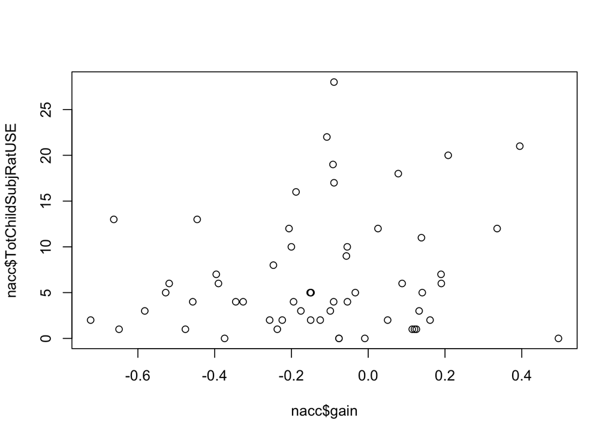

```r
plot(nacc$gain,nacc$TotChildSubjRatUSE)
```

```r
cor.test(nacc$gain, nacc$TotEventsExpUSE) #ns
```

```
##
##  Pearson's product-moment correlation
##
## data:  nacc$gain and nacc$TotEventsExpUSE
## t = 1.17, df = 56, p-value = 0.2469
## alternative hypothesis: true correlation is not equal to 0
## 95 percent confidence interval:
##  -0.1081  0.3970
## sample estimates:
##    cor
## 0.1545
```

```r
cor.test(nacc$gain, nacc$TotNumCategUSE) #ns
```

```
##
##  Pearson's product-moment correlation
##
## data:  nacc$gain and nacc$TotNumCategUSE
## t = 1.054, df = 56, p-value = 0.2964
## alternative hypothesis: true correlation is not equal to 0
## 95 percent confidence interval:
##  -0.1233  0.3839
## sample estimates:
##    cor
## 0.1395
```

```r
cor.test(nacc$gain, nacc$TotChildSubjRatUSE) #ns
```

```
##
##  Pearson's product-moment correlation
##
## data:  nacc$gain and nacc$TotChildSubjRatUSE
## t = 1.256, df = 56, p-value = 0.2142
## alternative hypothesis: true correlation is not equal to 0
## 95 percent confidence interval:
##  -0.09686  0.40649
## sample estimates:
##    cor
## 0.1656
```

```r
cor.test(nacc$loss, nacc$TotEventsExpUSE) #ns
```

```
##
##  Pearson's product-moment correlation
##
## data:  nacc$loss and nacc$TotEventsExpUSE
## t = -0.0438, df = 56, p-value = 0.9652
## alternative hypothesis: true correlation is not equal to 0
## 95 percent confidence interval:
##  -0.2637  0.2528
## sample estimates:
##       cor
## -0.005851
```

```r
cor.test(nacc$loss, nacc$TotNumCategUSE) #ns
```

```
##
##  Pearson's product-moment correlation
##
## data:  nacc$loss and nacc$TotNumCategUSE
## t = -0.115, df = 56, p-value = 0.9089
## alternative hypothesis: true correlation is not equal to 0
## 95 percent confidence interval:
##  -0.2726  0.2439
## sample estimates:
##      cor
## -0.01537
```

```r
cor.test(nacc$loss, nacc$TotChildSubjRatUSE) #ns
```

```
##
##  Pearson's product-moment correlation
##
## data:  nacc$loss and nacc$TotChildSubjRatUSE
## t = 0.2758, df = 56, p-value = 0.7837
## alternative hypothesis: true correlation is not equal to 0
## 95 percent confidence interval:
##  -0.2236  0.2923
## sample estimates:
##     cor
## 0.03683
```

```r
nacc$gainvnongain = nacc$gain - nacc$nongain
nacc$lossvnonloss = nacc$loss - nacc$nonloss

cor.test(nacc$gainvnongain,nacc$TotEventsExpUSE) # p = .087, r = .23
```

```
##
##  Pearson's product-moment correlation
##
## data:  nacc$gainvnongain and nacc$TotEventsExpUSE
## t = 1.744, df = 56, p-value = 0.08664
## alternative hypothesis: true correlation is not equal to 0
## 95 percent confidence interval:
##  -0.03327  0.45840
## sample estimates:
##   cor
## 0.227
```

```r
cor.test(nacc$gainvnongain, nacc$TotNumCategUSE) #ns
```

```
##
##  Pearson's product-moment correlation
##
## data:  nacc$gainvnongain and nacc$TotNumCategUSE
## t = 1.543, df = 56, p-value = 0.1285
## alternative hypothesis: true correlation is not equal to 0
## 95 percent confidence interval:
##  -0.05946  0.43742
## sample estimates:
##    cor
## 0.2019
```

```r
cor.test(nacc$gainvnongain, nacc$TotChildSubjRatUSE) #ns
```

```
##
##  Pearson's product-moment correlation
##
## data:  nacc$gainvnongain and nacc$TotChildSubjRatUSE
## t = 1.214, df = 56, p-value = 0.2299
## alternative hypothesis: true correlation is not equal to 0
## 95 percent confidence interval:
##  -0.1024  0.4018
## sample estimates:
##    cor
## 0.1601
```

```r
cor.test(nacc$lossvnonloss,nacc$TotEventsExpUSE) #ns
```

```
##
##  Pearson's product-moment correlation
##
## data:  nacc$lossvnonloss and nacc$TotEventsExpUSE
## t = -0.5443, df = 56, p-value = 0.5884
## alternative hypothesis: true correlation is not equal to 0
## 95 percent confidence interval:
##  -0.3248  0.1893
## sample estimates:
##      cor
## -0.07254
```

```r
cor.test(nacc$lossvnonloss, nacc$TotNumCategUSE) #ns
```

```
##
##  Pearson's product-moment correlation
##
## data:  nacc$lossvnonloss and nacc$TotNumCategUSE
## t = -0.6275, df = 56, p-value = 0.5329
## alternative hypothesis: true correlation is not equal to 0
## 95 percent confidence interval:
##  -0.3346  0.1786
## sample estimates:
##      cor
## -0.08356
```

```r
cor.test(nacc$lossvnonloss, nacc$TotChildSubjRatUSE) #ns
```

```
##
##  Pearson's product-moment correlation
##
## data:  nacc$lossvnonloss and nacc$TotChildSubjRatUSE
## t = -0.1726, df = 56, p-value = 0.8636
## alternative hypothesis: true correlation is not equal to 0
## 95 percent confidence interval:
##  -0.2797  0.2367
## sample estimates:
##      cor
## -0.02305
```

```r
summary(lm(nacc$gainvnongain ~ nacc$TotEventsExpUSE * nacc$ss.total, na.action = na.omit)) #ns
```

```
##
## Call:
## lm(formula = nacc$gainvnongain ~ nacc$TotEventsExpUSE * nacc$ss.total,
##     na.action = na.omit)
##
## Residuals:
##     Min      1Q  Median      3Q     Max
## -0.4696 -0.1233  0.0146  0.1026  0.3801
##
## Coefficients:
##                                     Estimate Std. Error t value Pr(>|t|)
## (Intercept)                        -9.51e-02   2.10e-01   -0.45     0.65
## nacc$TotEventsExpUSE                1.98e-02   3.76e-02    0.53     0.60
## nacc$ss.total                       8.32e-04   3.09e-03    0.27     0.79
## nacc$TotEventsExpUSE:nacc$ss.total -6.97e-05   5.56e-04   -0.13     0.90
##
## Residual standard error: 0.173 on 49 degrees of freedom
##   (5 observations deleted due to missingness)
## Multiple R-squared:  0.0804, Adjusted R-squared:  0.0241
## F-statistic: 1.43 on 3 and 49 DF,  p-value: 0.246
```

```r
summary(lm(nacc$gainvnongain ~ nacc$TotChildSubjRatUSE * nacc$Sex)) #significant with all 3 ELS variables - but the Child's subjective report is the most significant.
```

```
##
## Call:
## lm(formula = nacc$gainvnongain ~ nacc$TotChildSubjRatUSE * nacc$Sex)
##
## Residuals:
##     Min      1Q  Median      3Q     Max
## -0.4835 -0.1181  0.0206  0.0898  0.3034
##
## Coefficients:
##                                   Estimate Std. Error t value Pr(>|t|)
## (Intercept)                       -0.01096    0.03932   -0.28   0.7814
## nacc$TotChildSubjRatUSE            0.00834    0.00369    2.26   0.0280 *
## nacc$SexM                          0.13063    0.06918    1.89   0.0644 .
## nacc$TotChildSubjRatUSE:nacc$SexM -0.02770    0.00928   -2.99   0.0042 **
## ---
## Signif. codes:  0 '***' 0.001 '**' 0.01 '*' 0.05 '.' 0.1 ' ' 1
##
## Residual standard error: 0.164 on 54 degrees of freedom
## Multiple R-squared:  0.167,  Adjusted R-squared:  0.121
## F-statistic: 3.62 on 3 and 54 DF,  p-value: 0.0187
```

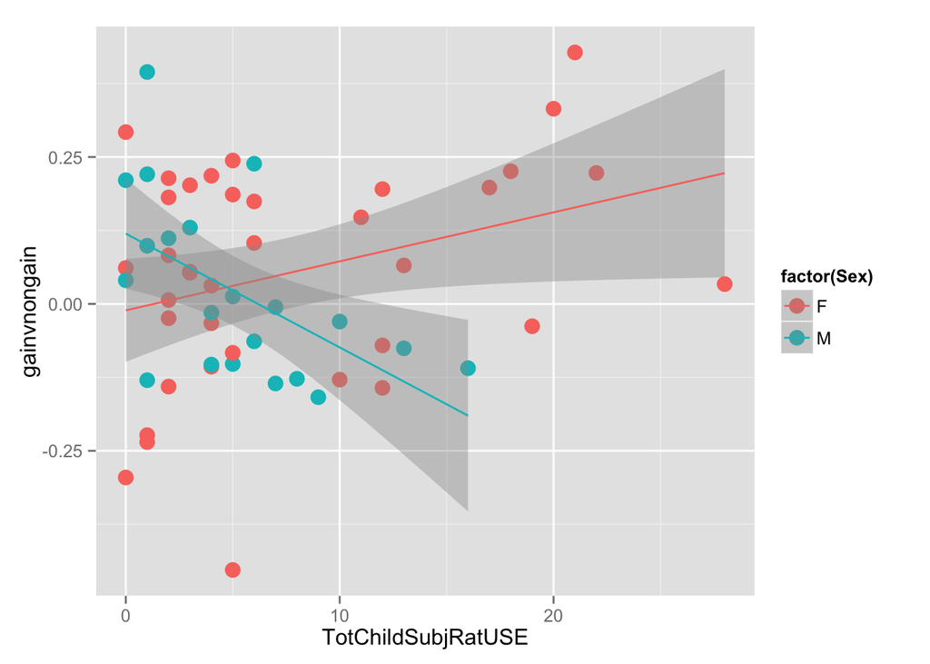

```r
m1 = lm(gainvnongain ~ TotChildSubjRatUSE + Sex + TotChildSubjRatUSE:Sex, data=nacc)
gp = ggplot(data = nacc, aes(x=TotChildSubjRatUSE, y = gainvnongain, color=factor(Sex)))
gp + geom_point(size=4) + stat_smooth(method="lm")
```

**There is a significant interaction between ELS and gender (37 females, 21 males) in the bilateral NAcc during the receipt of gains compared to nongain. Increased ELS is associated with decreased activation for gain > nongain, but only for males. For females, the pattern of activity is opposite: increased ELS is associated with increased activation, but the effect is weaker than for males.**

F(3,54) = 3.62, p = .019. The range of ELS scores is restricted for males (0-16).

```r
summary(lm(nacc$lossvnonloss ~ nacc$TotChildSubjRatUSE * nacc$Sex)) #ns
```

```
##
## Call:
## lm(formula = nacc$lossvnonloss ~ nacc$TotChildSubjRatUSE * nacc$Sex)
##
## Residuals:
##     Min      1Q  Median      3Q     Max
## -0.5618 -0.1613 -0.0041  0.1328  0.5325
##
## Coefficients:
##                                   Estimate Std. Error t value Pr(>|t|)
## (Intercept)                        0.02400    0.05715    0.42     0.68
## nacc$TotChildSubjRatUSE           -0.00123    0.00537   -0.23     0.82
## nacc$SexM                         -0.04497    0.10057   -0.45     0.66
## nacc$TotChildSubjRatUSE:nacc$SexM -0.00277    0.01349   -0.21     0.84
##
## Residual standard error: 0.239 on 54 degrees of freedom
## Multiple R-squared:  0.0164, Adjusted R-squared:  -0.0383
## F-statistic: 0.299 on 3 and 54 DF,  p-value: 0.826
```